# Two Way Convergence - null-Z approach

Tom Booker

07/05/2021

## Two Way Convergence

We’re interested in quantifying the extent of convergence between pairs of species in the CoAdapTree project.

We have 3 potential approaches for analysing 2-way convergence:

1. The Null-Z test (the Null-W test, but with WZA scores) (**asymmetric**)
2. A pMax style approach, what is the larger of the two p-values, is that smaller than you’d expect based on order statistic thinking (**symmetric**)
3. A contingency table approach, where you ask if the proportion of overlapping hits between two species is larger than you’d expect by chance (**symmetric**)

By **symmetric/asymmetric** I’m referring to a test that is dependant on the configuration of species that you put in. The null-W test is **assymetric** because the result depends on which species you put into the test first.

## 1. The null-Z approach

This test is straightforward to run directly on the WZA data.

Let’s simulate data under the null:

```r
twoSpeciesData <- cbind( sample(20000)/20000,
                        sample(20000)/20000)

head(twoSpeciesData)
```

```
##         [,1]    [,2]
## [1,] 0.33865 0.61525
## [2,] 0.35075 0.29265
## [3,] 0.71035 0.66930
## [4,] 0.01970 0.20495
## [5,] 0.95275 0.20400
## [6,] 0.96440 0.87505
```

Let’s grab the indices of the top 5% in both cases

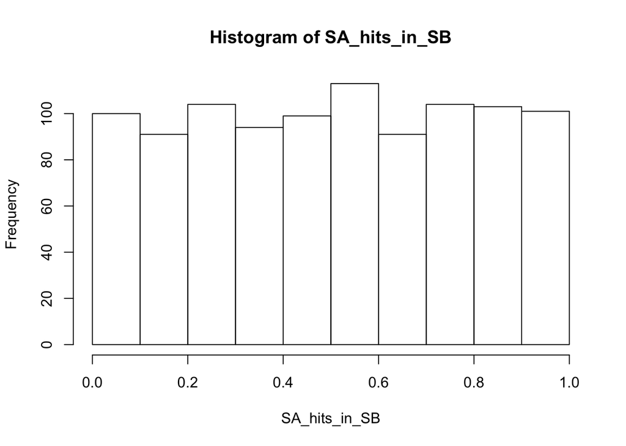

```r
twoSpeciesData_SA_hits <- twoSpeciesData[,1] < quantile(twoSpeciesData[,1],0.05)
twoSpeciesData_SB_hits <- twoSpeciesData[,2] < quantile(twoSpeciesData[,2],0.05)

SA_hits_in_SB <- twoSpeciesData[,2][ twoSpeciesData_SA_hits ]
SB_hits_in_SA <- twoSpeciesData[,1][ twoSpeciesData_SB_hits ]

hist(SA_hits_in_SB)
```

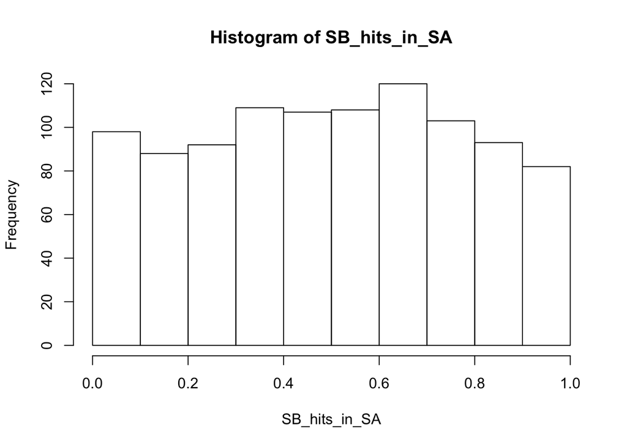

```r
hist(SB_hits_in_SA)

library(qvalue)
```

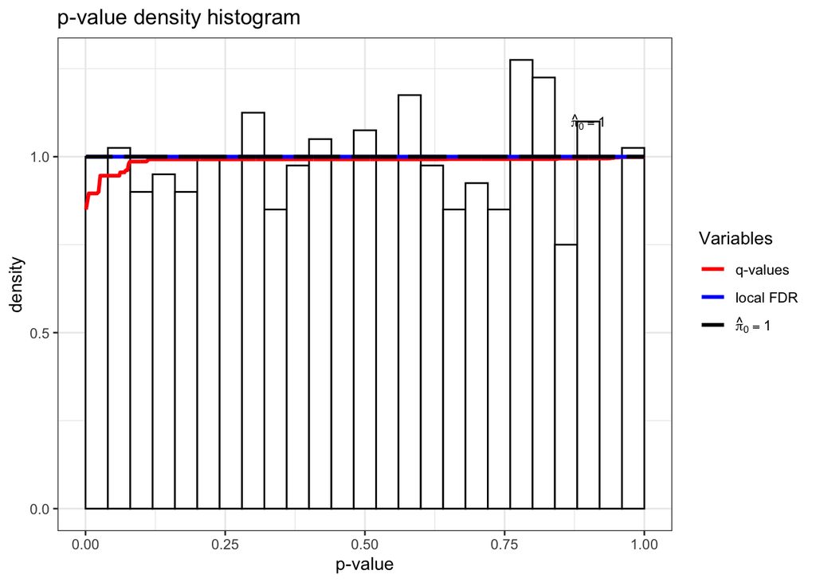

```r
hist(qvalue(SA_hits_in_SB))
```

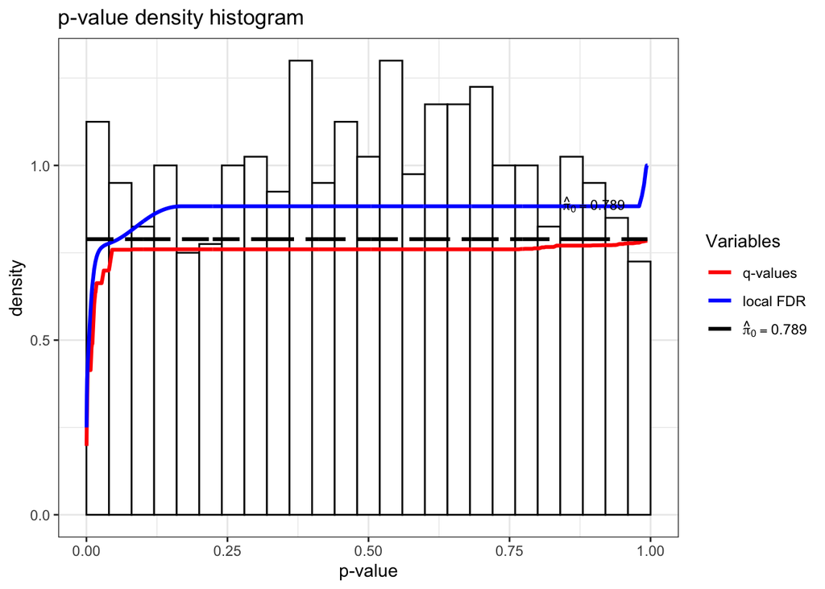

```r
hist(qvalue(SB_hits_in_SA))
```

## Test using WZA sims

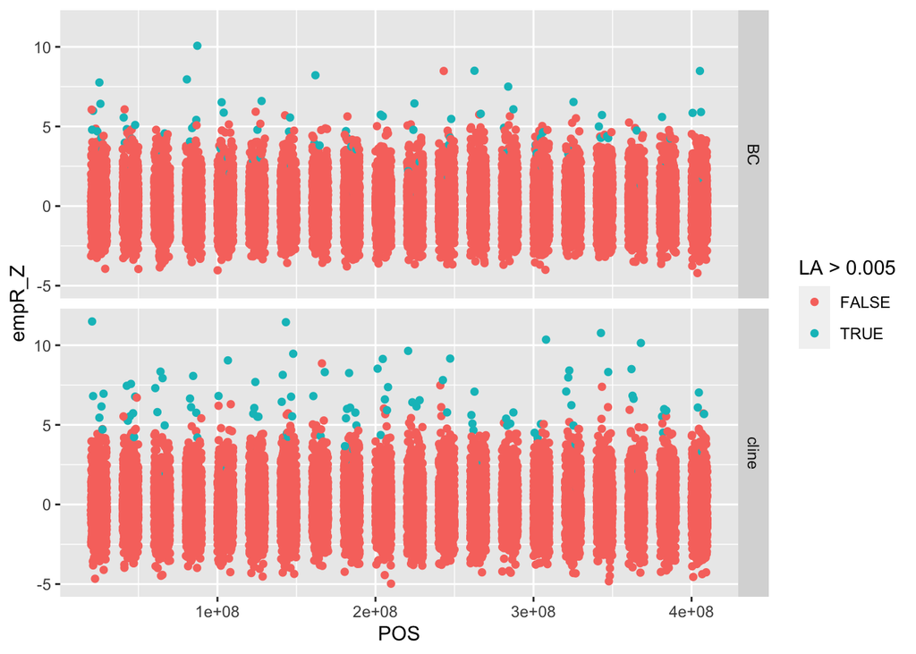

```r
cline <- read.csv("~/UBC/GEA/Convergence/WZA_results_for_testing/analysisFiles_s0.003/cline_sampled.WZA.csv")
cline_Stripped <- cline[,c(13,7,16,23, 24)]
cline_Stripped$POS <- round(cline_Stripped$position/10000)*10000 + cline_Stripped$rep*20e6
cline_Stripped$p <- 1 - rank(cline_Stripped$empR_Z)/length(cline_Stripped$empR_Z)

BC <- read.csv("~/UBC/GEA/Convergence/WZA_results_for_testing/analysisFiles_s0.003/BC_Map_sampled.WZA.csv")
BC_Stripped <- BC[,c(13,7,16,23, 24)]
BC_Stripped$POS <- round(BC_Stripped$position/10000)*10000 + BC_Stripped$rep*20e6
BC_Stripped$p <- 1 - rank(BC_Stripped$empR_Z)/length(BC_Stripped$empR_Z)

names (cline_Stripped) <- paste( "A", names(cline_Stripped), sep = "_")
names (BC_Stripped) <- paste( "B", names(BC_Stripped), sep = "_")

testDF <- merge(cline_Stripped, BC_Stripped,
      by.x = c("A_POS"),
      by.y = c("B_POS"))


library(ggplot2)

## For plotting
BC$map <- "BC"
BC$POS <- round(BC$position/10000)*10000 + BC$rep*20e6

cline$map <- "cline"
cline$POS <- round(cline$position/10000)*10000 + cline$rep*20e6

plot_DF <- rbind( BC, cline)

ggplot(data =plot_DF, aes(x = POS, y = empR_Z, col = LA > 0.005))+
  geom_point()+
  facet_grid(map~.)
```

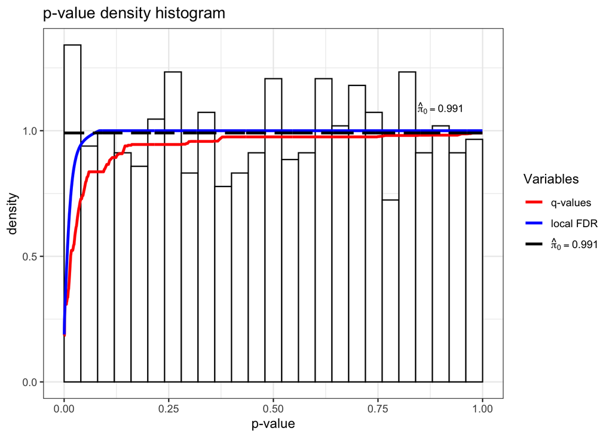

```r
true_Hits <- testDF[ (testDF$A_LA > 0.005)&(testDF$B_LA > 0.005) ,]

## Let's look at the top 5%
testDF_SA_hits <- testDF$A_p < 0.05
testDF_SB_hits <- testDF$B_p < 0.05

# Grab the reciprocal top 5% hits
SA_hits_in_SB <- testDF[ testDF_SA_hits ,]
SB_hits_in_SA <- testDF[ testDF_SB_hits ,]

# Plot it out
hist(qvalue(SB_hits_in_SA$A_p))
```

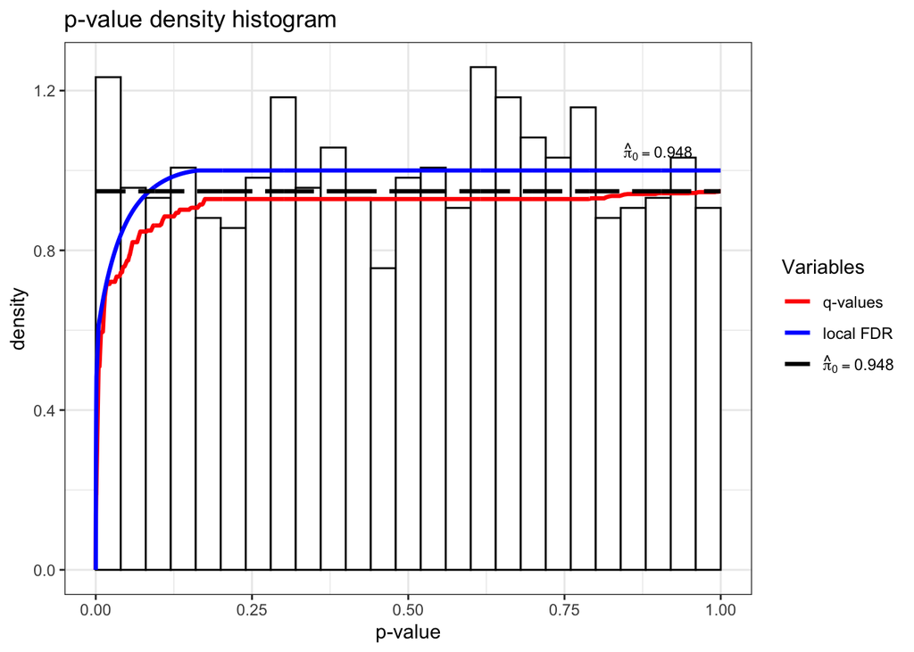

```r
hist(qvalue(SA_hits_in_SB$B_p))
```

```r
# How many true positives were there?
nrow(true_Hits)
```

```
## [1] 20
```

```r
# How many of the true positives did we detect?
sum(true_Hits$A_POS %in% SA_hits_in_SB$A_POS)
```

```
## [1] 20
```

```r
sum(true_Hits$A_POS %in% SB_hits_in_SA$A_POS)
```

```
## [1] 15
```